```python
pip install lightgbm
```

```python
pip install xgboost
```

# Objective

###### Predict if a driver will file an insurance claim next year

# Data

- Source of the data is kaggle, Porto Seguro Driver's Prediction Challenge.
- Features that belong to similar groupings are tagged as such in the feature names (e.g., ind, reg, car, calc).
- Feature names include the postfix bin to indicate binary features and cat to indicate categorical features.
- Features without these designations are either continuous or ordinal.
- Values of -1 indicate that the feature was missing from the observation.
- The target columns signifies whether or not a claim was filed for that policy holder.

# Import packages

```python
# libraries
import pandas as pd
import numpy as np
import seaborn as sns
import scipy as sp
import matplotlib.pyplot as plt

from sklearn.preprocessing import Imputer
from sklearn.pipeline import Pipeline
from sklearn.pipeline import make_pipeline
from sklearn.preprocessing import StandardScaler
from sklearn.model_selection import GridSearchCV
from sklearn.model_selection import RandomizedSearchCV


from sklearn.model_selection import train_test_split
from sklearn.linear_model import LogisticRegression
from sklearn.ensemble import RandomForestClassifier
from xgboost import XGBClassifier
from sklearn.model_selection import cross_val_score
from lightgbm import LGBMClassifier
import lightgbm as lgb

from sklearn.pipeline import Pipeline

#import xgboost as xgb
#from sklearn.model_selection import KFold
#from sklearn.model_selection import train_test_split
```

# Load Date

```python
train  = pd.read_csv('C:/Users/royag/Desktop/Resume and Cover Letter/Interview projects/train.csv')
test = pd.read_csv('C:/Users/royag/Desktop/Resume and Cover Letter/Interview projects/test.csv')
```

```python
#print (train.shape)
#print (test.shape)

print ('train set: # of rows = {} and # of columns = {}' .format (train.shape[0], train.shape[1]))
print ('test set:  # of rows = {} and # of columns = {}' .format (test.shape[0], test.shape[1]))
```

```
train set: # of rows = 595212 and # of columns = 59
test set:  # of rows = 892816 and # of columns = 58
```

```python
#train.head()
train.columns
```

```
Index(['id', 'target', 'ps_ind_01', 'ps_ind_02_cat', 'ps_ind_03',
       'ps_ind_04_cat', 'ps_ind_05_cat', 'ps_ind_06_bin', 'ps_ind_07_bin',
       'ps_ind_08_bin', 'ps_ind_09_bin', 'ps_ind_10_bin', 'ps_ind_11_bin',
       'ps_ind_12_bin', 'ps_ind_13_bin', 'ps_ind_14', 'ps_ind_15',
       'ps_ind_16_bin', 'ps_ind_17_bin', 'ps_ind_18_bin', 'ps_reg_01',
       'ps_reg_02', 'ps_reg_03', 'ps_car_01_cat', 'ps_car_02_cat',
       'ps_car_03_cat', 'ps_car_04_cat', 'ps_car_05_cat', 'ps_car_06_cat',
       'ps_car_07_cat', 'ps_car_08_cat', 'ps_car_09_cat', 'ps_car_10_cat',
       'ps_car_11_cat', 'ps_car_11', 'ps_car_12', 'ps_car_13', 'ps_car_14',
       'ps_car_15', 'ps_calc_01', 'ps_calc_02', 'ps_calc_03', 'ps_calc_04',
       'ps_calc_05', 'ps_calc_06', 'ps_calc_07', 'ps_calc_08', 'ps_calc_09',
       'ps_calc_10', 'ps_calc_11', 'ps_calc_12', 'ps_calc_13', 'ps_calc_14',
       'ps_calc_15_bin', 'ps_calc_16_bin', 'ps_calc_17_bin', 'ps_calc_18_bin',
       'ps_calc_19_bin', 'ps_calc_20_bin'],
      dtype='object')
```

```python
#train.tail()
```

## Duplicate rows

Look at the number of rows and columns in the train data and the test data. Check if we have the same number of variables in the test data. Check if there are duplicate rows in the training data.

```python
print (train.shape)
print (test.shape)

train.drop_duplicates()

print (train.shape)
```

```
(595212, 59)
(892816, 58)
(595212, 59)
```

- Target variable is missing in test data set
- There is no duplicate rows

## Data type

Invesigate how many variables of each type we have.

```python
train.info()
```

```
<class 'pandas.core.frame.DataFrame'>
RangeIndex: 595212 entries, 0 to 595211
Data columns (total 59 columns):
id                595212 non-null int64
target            595212 non-null int64
ps_ind_01         595212 non-null int64
ps_ind_02_cat     595212 non-null int64
ps_ind_03         595212 non-null int64
ps_ind_04_cat     595212 non-null int64
ps_ind_05_cat     595212 non-null int64
ps_ind_06_bin     595212 non-null int64
ps_ind_07_bin     595212 non-null int64
ps_ind_08_bin     595212 non-null int64
ps_ind_09_bin     595212 non-null int64
ps_ind_10_bin     595212 non-null int64
ps_ind_11_bin     595212 non-null int64
ps_ind_12_bin     595212 non-null int64
ps_ind_13_bin     595212 non-null int64
ps_ind_14         595212 non-null int64
ps_ind_15         595212 non-null int64
ps_ind_16_bin     595212 non-null int64
ps_ind_17_bin     595212 non-null int64
ps_ind_18_bin     595212 non-null int64
ps_reg_01         595212 non-null float64
ps_reg_02         595212 non-null float64
ps_reg_03         595212 non-null float64
ps_car_01_cat     595212 non-null int64
ps_car_02_cat     595212 non-null int64
ps_car_03_cat     595212 non-null int64
ps_car_04_cat     595212 non-null int64
ps_car_05_cat     595212 non-null int64
ps_car_06_cat     595212 non-null int64
ps_car_07_cat     595212 non-null int64
ps_car_08_cat     595212 non-null int64
ps_car_09_cat     595212 non-null int64
ps_car_10_cat     595212 non-null int64
ps_car_11_cat     595212 non-null int64
ps_car_11         595212 non-null int64
ps_car_12         595212 non-null float64
ps_car_13         595212 non-null float64
```

[output cut: 9 more lines]

```
ps_calc_08        595212 non-null int64
ps_calc_09        595212 non-null int64
ps_calc_10        595212 non-null int64
ps_calc_11        595212 non-null int64
ps_calc_12        595212 non-null int64
ps_calc_13        595212 non-null int64
ps_calc_14        595212 non-null int64
ps_calc_15_bin    595212 non-null int64
ps_calc_16_bin    595212 non-null int64
ps_calc_17_bin    595212 non-null int64
ps_calc_18_bin    595212 non-null int64
ps_calc_19_bin    595212 non-null int64
ps_calc_20_bin    595212 non-null int64
dtypes: float64(10), int64(49)
memory usage: 267.9 MB
```

```python
#make a copy of data sets
train_set=train.copy()
test_set=test.copy()
```

### Variable information in a dataframe

- **role**: input, ID, target
- **level**: Categorical, Real, Integer, Binary
- **drop**: True or False
- **category**: calculated, individual, registration, car
- **dtype**: int, float, str

```python
data=[]
for var in train_set.columns:
    # define the role of the features
    if var=='target':
        role='target'
    elif var=='id':
        role='id'
    else:
        role='input'

    #define the level of the features
    if 'bin' in var or var=='target':
        level='binary'
        #print (level)
    elif 'cat' in var or var=='id':
        level='categorical'
    elif train_set[var].dtype==float:
        level = 'real'
    else:
        level='integer'

    # Defining the category of the features
    category='00'
    if 'ind' in var:
        category = 'individual'
    elif 'reg' in var:
        category = 'registration'
    elif 'car' in var:
        category = 'car'
    else:
        category = 'calculated'

    # define new boolean var to decide about keeping or dropping the features
    drop=False
    if var=='id':
        drop=True

    # define type of the features
    dtype = train_set[var].dtype

    my_dic= {'varname':var, 'role': role, 'level':level, 'drop':drop, 'category':category, 'dtype': dtype}

    data.append (my_dic)

table_1= pd.DataFrame(data , columns=['varname', 'role' , 'level', 'drop', 'category', 'dtype'])

table_1.set_index('varname', inplace=True)
```

```python
table_1
```

| varname | role | level | drop | category | dtype |
| --- | --- | --- | --- | --- | --- |
| id | id | categorical | True | calculated | int64 |
| target | target | binary | False | calculated | int64 |
| ps_ind_01 | input | integer | False | individual | int64 |
| ps_ind_02_cat | input | categorical | False | individual | int64 |
| ps_ind_03 | input | integer | False | individual | int64 |
| ps_ind_04_cat | input | categorical | False | individual | int64 |
| ps_ind_05_cat | input | categorical | False | individual | int64 |
| ps_ind_06_bin | input | binary | False | individual | int64 |
| ps_ind_07_bin | input | binary | False | individual | int64 |
| ps_ind_08_bin | input | binary | False | individual | int64 |
| ps_ind_09_bin | input | binary | False | individual | int64 |
| ps_ind_10_bin | input | binary | False | individual | int64 |
| ps_ind_11_bin | input | binary | False | individual | int64 |
| ps_ind_12_bin | input | binary | False | individual | int64 |
| ps_ind_13_bin | input | binary | False | individual | int64 |
| ps_ind_14 | input | integer | False | individual | int64 |
| ps_ind_15 | input | integer | False | individual | int64 |
| ps_ind_16_bin | input | binary | False | individual | int64 |
| ps_ind_17_bin | input | binary | False | individual | int64 |
| ps_ind_18_bin | input | binary | False | individual | int64 |
| ps_reg_01 | input | real | False | registration | float64 |
| ps_reg_02 | input | real | False | registration | float64 |
| ps_reg_03 | input | real | False | registration | float64 |
| ps_car_01_cat | input | categorical | False | car | int64 |
| ps_car_02_cat | input | categorical | False | car | int64 |
| ps_car_03_cat | input | categorical | False | car | int64 |
| ps_car_04_cat | input | categorical | False | car | int64 |
| ps_car_05_cat | input | categorical | False | car | int64 |
| ps_car_06_cat | input | categorical | False | car | int64 |
| ps_car_07_cat | input | categorical | False | car | int64 |
| ps_car_08_cat | input | categorical | False | car | int64 |
| ps_car_09_cat | input | categorical | False | car | int64 |
| ps_car_10_cat | input | categorical | False | car | int64 |
| ps_car_11_cat | input | categorical | False | car | int64 |
| ps_car_11 | input | integer | False | car | int64 |
| ps_car_12 | input | real | False | car | float64 |
| ps_car_13 | input | real | False | car | float64 |
| ps_car_14 | input | real | False | car | float64 |
| ps_car_15 | input | real | False | car | float64 |
| ps_calc_01 | input | real | False | calculated | float64 |
| ps_calc_02 | input | real | False | calculated | float64 |
| ps_calc_03 | input | real | False | calculated | float64 |
| ps_calc_04 | input | integer | False | calculated | int64 |
| ps_calc_05 | input | integer | False | calculated | int64 |
| ps_calc_06 | input | integer | False | calculated | int64 |
| ps_calc_07 | input | integer | False | calculated | int64 |
| ps_calc_08 | input | integer | False | calculated | int64 |
| ps_calc_09 | input | integer | False | calculated | int64 |
| ps_calc_10 | input | integer | False | calculated | int64 |
| ps_calc_11 | input | integer | False | calculated | int64 |
| ps_calc_12 | input | integer | False | calculated | int64 |
| ps_calc_13 | input | integer | False | calculated | int64 |
| ps_calc_14 | input | integer | False | calculated | int64 |
| ps_calc_15_bin | input | binary | False | calculated | int64 |
| ps_calc_16_bin | input | binary | False | calculated | int64 |
| ps_calc_17_bin | input | binary | False | calculated | int64 |
| ps_calc_18_bin | input | binary | False | calculated | int64 |
| ps_calc_19_bin | input | binary | False | calculated | int64 |
| ps_calc_20_bin | input | binary | False | calculated | int64 |

```python
# extract categorical data

table_1[(table_1.level == 'categorical')].index
```

```
Index(['id', 'ps_ind_02_cat', 'ps_ind_04_cat', 'ps_ind_05_cat',
       'ps_car_01_cat', 'ps_car_02_cat', 'ps_car_03_cat', 'ps_car_04_cat',
       'ps_car_05_cat', 'ps_car_06_cat', 'ps_car_07_cat', 'ps_car_08_cat',
       'ps_car_09_cat', 'ps_car_10_cat', 'ps_car_11_cat'],
      dtype='object', name='varname')
```

```python
# number of variables per role and level

pd.DataFrame({'count': table_1.groupby(['level', 'dtype'])['level'].size()}).reset_index()
```

|  | level | dtype | count |
| --- | --- | --- | --- |
| 0 | binary | int64 | 18 |
| 1 | categorical | int64 | 15 |
| 2 | integer | int64 | 16 |
| 3 | real | float64 | 10 |

# Exploring the data

## - Target value

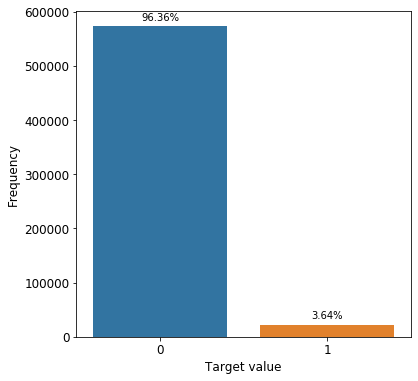

```python
plt.figure()
fig, ax = plt.subplots(figsize=(6,6))
x = train_set['target'].value_counts().index.values
y = train_set['target'].value_counts().values
# Bar plot
# Order the bars descending on target mean
sns.barplot(ax=ax, x=x, y=y)
plt.ylabel('Frequency', fontsize=12)
plt.xlabel('Target value', fontsize=12)
plt.tick_params(axis='both', which='major', labelsize=12)
for p in ax.patches:
    percentage = '{:.2f}%'.format(100 * p.get_height()/len(train_set))
    ax.annotate(percentage,(p.get_x() + p.get_width()/2 , p.get_y()+ p.get_height()), \
                   ha = 'center', va = 'center', xytext = (0, 9),textcoords = 'offset points')
# for p in ax.patches:
#        ax.text(p.get_x(), p.get_height(), str(round((p.get_height()/len(train_set))*100, 2))+'%', fontsize=15, color='black',\
#                ha='center' , va='center')

plt.show();
```

```python
train_set['target'].value_counts()
```

```
0    573518
1     21694
Name: target, dtype: int64
```

## - Categorical Varibles

```python
cat_vars = [e for e in train_set.columns if e.endswith('cat')]

for e in cat_vars:
    dist_values = train_set[e].value_counts().shape[0]
    print('Variable {} has {} distinct values'.format(e, dist_values))
```

```
Variable ps_ind_02_cat has 5 distinct values
Variable ps_ind_04_cat has 3 distinct values
Variable ps_ind_05_cat has 8 distinct values
Variable ps_car_01_cat has 13 distinct values
Variable ps_car_02_cat has 3 distinct values
Variable ps_car_03_cat has 3 distinct values
Variable ps_car_04_cat has 10 distinct values
Variable ps_car_05_cat has 3 distinct values
Variable ps_car_06_cat has 18 distinct values
Variable ps_car_07_cat has 3 distinct values
Variable ps_car_08_cat has 2 distinct values
Variable ps_car_09_cat has 6 distinct values
Variable ps_car_10_cat has 3 distinct values
Variable ps_car_11_cat has 104 distinct values
```

```
ps_ind_02_cat
```

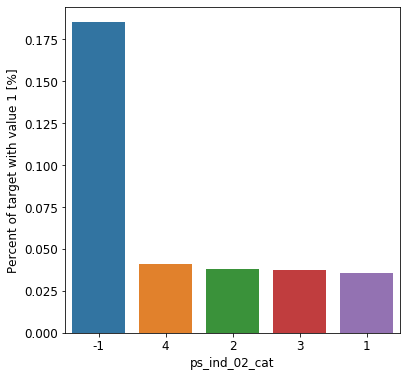

```
ps_ind_04_cat
```

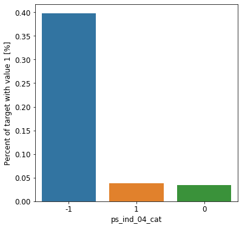

```
ps_ind_05_cat
```

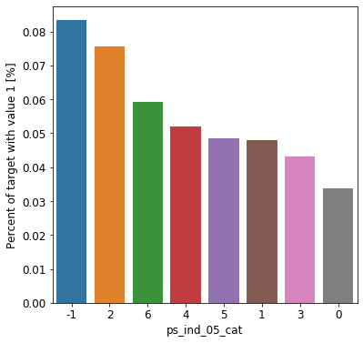

```
ps_car_01_cat
```

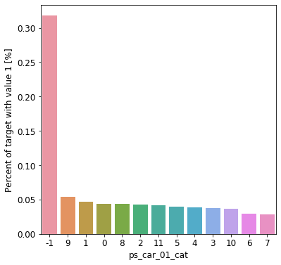

```
ps_car_02_cat
```

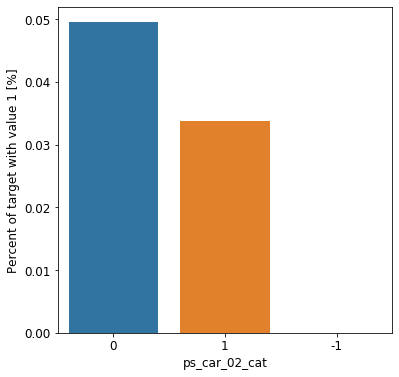

```
ps_car_03_cat
```

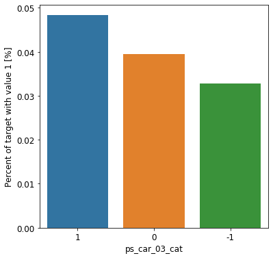

```
ps_car_04_cat
```

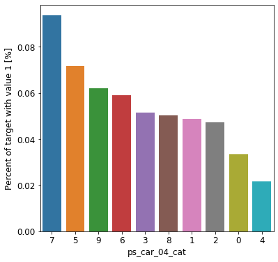

```
ps_car_05_cat
```

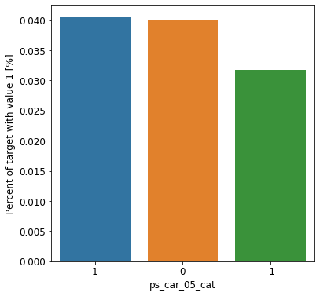

```
ps_car_06_cat
```

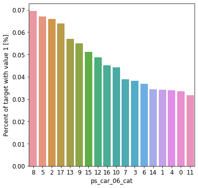

```
ps_car_07_cat
```

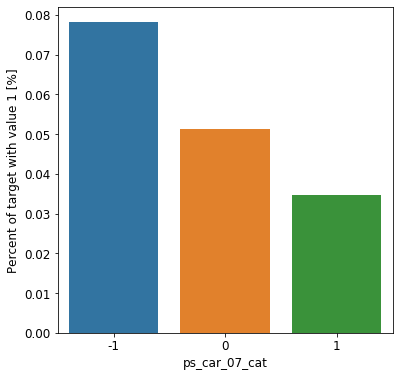

```
ps_car_08_cat
```

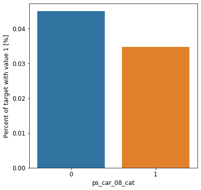

```
ps_car_09_cat
```

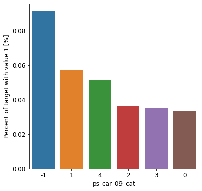

```
ps_car_10_cat
```

[2 more figures not shown]

```python
for f in cat_vars:
    print (f)
    fig, ax = plt.subplots(figsize=(6,6))
    # Calculate the percentage of target=1 per category value
    cat_percentage = train_set[[f, 'target']].groupby([f],as_index=False).mean()
    cat_percentage.sort_values(by='target', ascending=False, inplace=True)
    # Bar plot
    # Order the bars descending on target mean
    sns.barplot(ax=ax,x=f, y='target', data=cat_percentage, order=cat_percentage[f])
    plt.ylabel('Percent of target with value 1 [%]', fontsize=12)
    plt.xlabel(f , fontsize=12)
    plt.tick_params(axis='both', which='major', labelsize=12)
    plt.show();
```

# Data Preprocessing

```python
#train_set.iloc[:, 2:].columns
# for i in range(train_set.shape[1]-2):
#     plt.boxplot(train_set.iloc[:, i])
#     plt.show()
```

## - check missing values

```python
missingValues1 = []
missingPer1=[]

for i in train_set.columns:
    missings1 = train_set[train_set[i] == -1][i].count()
    if missings1 > 0:
        missingValues1.append(i)
        missingPer1.append(missings1/train_set.shape[0])
        missingPercent1 = missings1/train_set.shape[0]

        print('Variable {} in train data has {} records ({:.2%}) with missing values'.format(i, missings1, missingPercent1))

print('In total, there are {} variables with missing values in train data'.format(len(missingValues1)))


missingValues2 = []
missingPer2=[]


for i in test_set.columns:
    missings2 = test_set[test_set[i] == -1][i].count()
    if missings2 > 0:
        missingValues2.append(i)
        missingPer2.append(missings2/test_set.shape[0])
        missingPercent2 = missings2/test_set.shape[0]

        print('Variable {} in test data has {} records ({:.2%}) with missing values'.format(i, missings2, missingPercent2))

print('In total, there are {} variables with missing values in test data'.format(len(missingValues2)))
```

```
Variable ps_ind_02_cat in train data has 216 records (0.04%) with missing values
Variable ps_ind_04_cat in train data has 83 records (0.01%) with missing values
Variable ps_ind_05_cat in train data has 5809 records (0.98%) with missing values
Variable ps_reg_03 in train data has 107772 records (18.11%) with missing values
Variable ps_car_01_cat in train data has 107 records (0.02%) with missing values
Variable ps_car_02_cat in train data has 5 records (0.00%) with missing values
Variable ps_car_03_cat in train data has 411231 records (69.09%) with missing values
Variable ps_car_05_cat in train data has 266551 records (44.78%) with missing values
Variable ps_car_07_cat in train data has 11489 records (1.93%) with missing values
Variable ps_car_09_cat in train data has 569 records (0.10%) with missing values
Variable ps_car_11 in train data has 5 records (0.00%) with missing values
Variable ps_car_12 in train data has 1 records (0.00%) with missing values
Variable ps_car_14 in train data has 42620 records (7.16%) with missing values
In total, there are 13 variables with missing values in train data
Variable ps_ind_02_cat in test data has 307 records (0.03%) with missing values
Variable ps_ind_04_cat in test data has 145 records (0.02%) with missing values
Variable ps_ind_05_cat in test data has 8710 records (0.98%) with missing values
Variable ps_reg_03 in test data has 161684 records (18.11%) with missing values
Variable ps_car_01_cat in test data has 160 records (0.02%) with missing values
Variable ps_car_02_cat in test data has 5 records (0.00%) with missing values
Variable ps_car_03_cat in test data has 616911 records (69.10%) with missing values
Variable ps_car_05_cat in test data has 400359 records (44.84%) with missing values
Variable ps_car_07_cat in test data has 17331 records (1.94%) with missing values
Variable ps_car_09_cat in test data has 877 records (0.10%) with missing values
Variable ps_car_11 in test data has 1 records (0.00%) with missing values
Variable ps_car_14 in test data has 63805 records (7.15%) with missing values
In total, there are 12 variables with missing values in test data
```

### - Visualize the missing values of the features

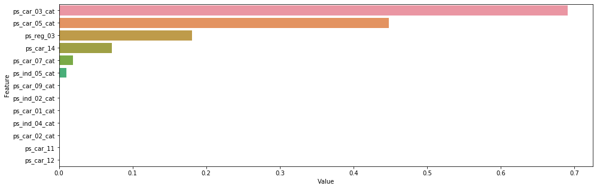

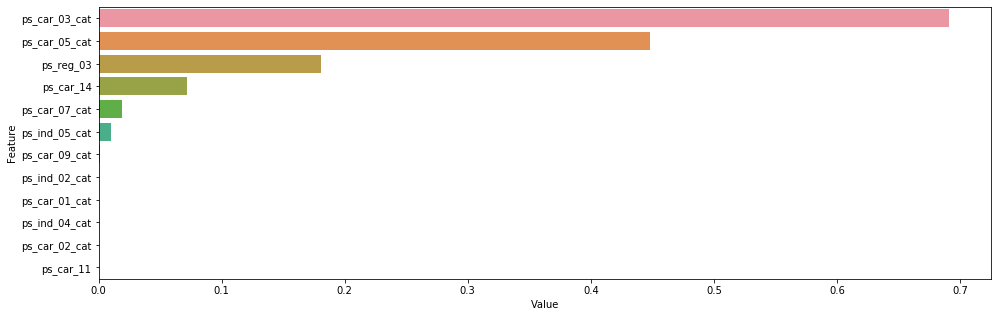

```python
missing_vars1 = pd.DataFrame(sorted(zip(missingPer1, missingValues1)), columns=["Value", "Feature"])
plt.figure(figsize=(16, 5))
sns.barplot(x="Value", y="Feature", data=missing_vars1.sort_values(by="Value", ascending=False))


missing_vars2 = pd.DataFrame(sorted(zip(missingPer2, missingValues2)), columns=["Value", "Feature"])
plt.figure(figsize=(16, 5))
sns.barplot(x="Value", y="Feature", data=missing_vars2.sort_values(by="Value", ascending=False))
```

### - Drop variables with too many missing values

```python
vars_drop = ['ps_car_03_cat', 'ps_car_05_cat']
#vars_drop = ['ps_reg_03', 'ps_car_14']
train_set.drop(vars_drop, inplace=True, axis=1)
test_set.drop(vars_drop, inplace=True, axis=1)

#table_1.loc[(vars_drop),'drop'] = True  # Updating table_1
```

### - Replace -1 values with NaN

```python
train_set = train_set.replace(-1, np.nan)
test_set = test_set.replace(-1, np.nan)
```

### - Imputing the missing values

```python
cat_cols = [c for c in train_set.columns if 'cat' in c]
bin_cols = [c for c in train_set.columns if 'bin' in c]
con_cols = [c for c in train_set.columns if c not in (bin_cols + cat_cols) ]   #real and integer
del con_cols[:2]


print (con_cols)

# Imputing with the mean or mode
mean_imp = Imputer(missing_values=np.nan , strategy='mean', axis=0)
mode_imp = Imputer(missing_values=np.nan , strategy='most_frequent', axis=0)

for c in cat_cols:
    train_set[c] = mode_imp.fit_transform(train_set[[c]]).ravel()
    test_set[c] = mode_imp.transform(test_set[[c]]).ravel()

for c in bin_cols:
    train_set[c] = mean_imp.fit_transform(train_set[[c]]).ravel()
    test_set[c] = mean_imp.transform(test_set[[c]]).ravel()

for c in con_cols:
    train_set[c] = mean_imp.fit_transform(train_set[[c]]).ravel()
    test_set[c] = mean_imp.transform(test_set[[c]]).ravel()

"""
for c in cat_cols:
    train_set[c].fillna(value=train_set[c].mode()[0], inplace=True)
    test_set[c].fillna(value=test_set[c].mode()[0], inplace=True)


for c in bin_cols:
    train_set[c].fillna(value=train_set[c].mode()[0], inplace=True)
    test_set[c].fillna(value=test_set[c].mode()[0], inplace=True)

for c in con_cols:
    train_set[c].fillna(value=train_df[c].mean(), inplace=True)
    test_set[c].fillna(value=test_df[c].mean(), inplace=True)

"""
```

```
['ps_ind_01', 'ps_ind_03', 'ps_ind_14', 'ps_ind_15', 'ps_reg_01', 'ps_reg_02', 'ps_reg_03', 'ps_car_11', 'ps_car_12', 'ps_car_13', 'ps_car_14', 'ps_car_15', 'ps_calc_01', 'ps_calc_02', 'ps_calc_03', 'ps_calc_04', 'ps_calc_05', 'ps_calc_06', 'ps_calc_07', 'ps_calc_08', 'ps_calc_09', 'ps_calc_10', 'ps…
```

```
'\nfor c in cat_cols:\n    train_set[c].fillna(value=train_set[c].mode()[0], inplace=True)\n    test_set[c].fillna(value=test_set[c].mode()[0], inplace=True)\n    \n    \nfor c in bin_cols:\n    train_set[c].fillna(value=train_set[c].mode()[0], inplace=True)\n    test_set[c].fillna(value=test_set[c]…
```

## - Corrolation between the variables

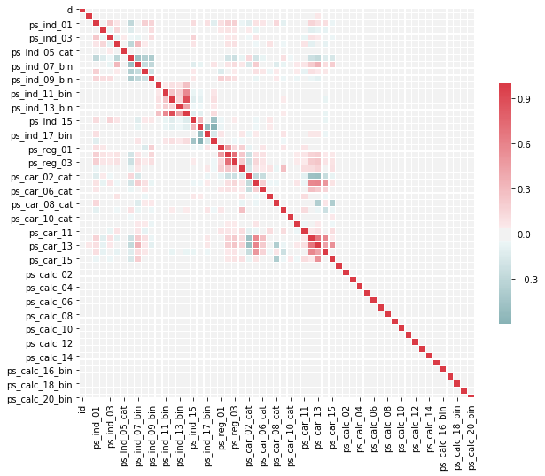

```python
correlations = train_set.corr()

# Create color map ranging between two colors
cmap = sns.diverging_palette(200, 10, as_cmap=True)

fig, ax = plt.subplots(figsize=(10,10))
sns.heatmap(correlations, cmap=cmap, vmax=1, center=0, fmt='.2f',
                square=True, linewidths=.25, annot=False, cbar_kws={"shrink": .5})
plt.show();
```

### - Find highly correlated Vars

```python
for i in correlations.columns:
    for j in correlations.columns:
        if (correlations[i][j])>0.5 and j>i:
            print ('{} and {} ({:.2%})'.format (i , j , correlations[i][j]))
```

```
ps_ind_11_bin and ps_ind_14 (56.49%)
ps_ind_12_bin and ps_ind_14 (89.01%)
ps_reg_02 and ps_reg_03 (70.31%)
ps_car_04_cat and ps_car_12 (57.04%)
ps_car_04_cat and ps_car_13 (59.52%)
ps_car_12 and ps_car_13 (67.20%)
ps_car_12 and ps_car_14 (57.75%)
ps_car_13 and ps_car_15 (52.95%)
```

```python
#vars_drop = ['ps_ind_14', 'ps_car_13', 'ps_car_04_cat']

# train_set.drop(vars_drop, inplace=True, axis=1)
# test_set.drop(vars_drop, inplace=True, axis=1)
```

## - Dummify categorical variables

```python
cat_vars  = [e for e in train_set.columns if e.endswith('cat')]

def encode_cat_vars(df, cat_vars):
    for c in cat_vars:
        temp = pd.get_dummies(pd.Series(df[c]), prefix=c)
        df = pd.concat([df, temp],axis=1)
        df = df.drop([c],axis=1)
    return df

train_set = encode_cat_vars(train_set, cat_vars)
test_set = encode_cat_vars(test_set, cat_vars)
```

```python
print(train_set.shape)
print(test_set.shape)
```

```
(595212, 216)
(892816, 215)
```

```python
train_target = train_set['target']
train_target_value = train_set['target'].values
train_y= np.array(train['target'])
train_id= train['id']
train_id_value= train['id'].values
test_id=test['id']
test_id_value=test['id'].values
```

### - Drop "id" and "target" columns from both train and test set

```python
train_set = train_set.drop(['target','id'], axis = 1)
test_set = test_set.drop(['id'], axis = 1)
```

## - Feature Selection

```
[LightGBM] [Warning] min_data_in_leaf is set=1, min_child_samples=20 will be ignored. Current value: min_data_in_leaf=1
[LightGBM] [Warning] min_sum_hessian_in_leaf is set=1.0, min_child_weight=0.001 will be ignored. Current value: min_sum_hessian_in_leaf=1.0
     Value            Feature
0        0  ps_car_10_cat_2.0
1        7  ps_car_04_cat_5.0
2        8  ps_car_04_cat_7.0
3        8      ps_ind_11_bin
4        9      ps_ind_10_bin
..     ...                ...
209   2244         ps_calc_10
210   2377          ps_ind_15
211   2688          ps_car_14
212   3984          ps_car_13
213   4447          ps_reg_03

[214 rows x 2 columns]
```

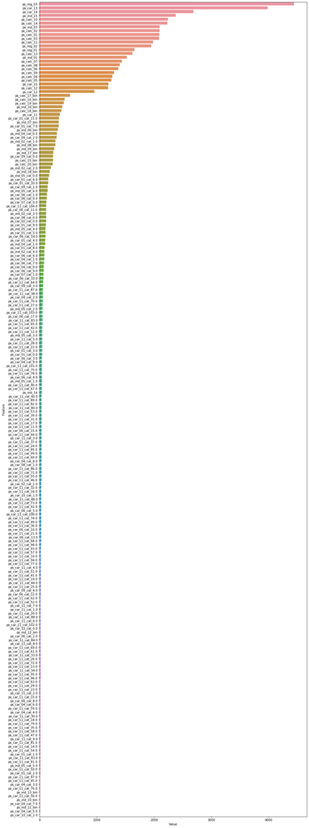

```python
model = LGBMClassifier(n_estimators=2000, learning_rate=0.1, max_depth=-1, min_data_in_leaf = 1, min_sum_hessian_in_leaf = 1.0)
#model= RandomForestClassifier(n_estimators=1000, random_state=0, n_jobs=-1)
X = train_set
y = train_target_value
#y = train_target

model.fit(X, y)

features_imp = pd.DataFrame(sorted(zip(model.feature_importances_, X.columns)), columns=["Value", "Feature"])

print (features_imp)

plt.figure(figsize=(16, 50))
sns.barplot(x="Value", y="Feature", data=features_imp.sort_values(by="Value", ascending=False))
```

### - Drop the features that are not significant

```python
sorted_columns = sorted(zip(model.feature_importances_, X.columns))
# print (sorted_columns_by_fi)
col_to_drop = [x[1] for x in sorted_columns if x[0] < 100]
#col_to_drop = [x[1] for x in sorted_columns if x[0] < 0.0025]
#print (col_to_drop)
train_set_imp = train_set.drop(col_to_drop, axis=1)
test_set_imp = test_set.drop(col_to_drop, axis=1)
```

### - Drop calculated features

```python
col_drop = train_set.columns[train_set.columns.str.startswith('ps_calc_')]
train_WOCalc = train_set_imp.drop(col_drop, axis=1)
test_WOCalc = test_set_imp.drop(col_drop, axis=1)
```

```python
print(train_set_imp.shape)
print(train_WOCalc.shape)
print(test_set_imp.shape)
print(test_WOCalc.shape)
```

```
(595212, 62)
(595212, 42)
(892816, 62)
(892816, 42)
```

# Scaling and preparing models

### XGBoost

```python
pipe_steps = [('scaler', StandardScaler()), ('xgboost',XGBClassifier())]

params = {
        'xgboost__min_child_weight': [5, 10],
        'xgboost__gamma': [2, 5],
        'xgboost__subsample': [ 0.8, 1.0],
        'xgboost__colsample_bytree': [0.8, 1.0],
        'xgboost__max_depth': [4, 5]
        }

pipeline = Pipeline(pipe_steps)

#X= train_set_imp
X = train_WOCalc
y = train_target_value
```

```python
cv_xgb  = GridSearchCV(pipeline, params, cv=10, scoring='roc_auc')
#cv_xgb = RandomizedSearchCV(pipeline, params, cv=10, scoring='roc_auc')
```

```python
print (cv_xgb)
```

```
GridSearchCV(cv=10, error_score='raise-deprecating',
             estimator=Pipeline(memory=None,
                                steps=[('scaler',
                                        StandardScaler(copy=True,
                                                       with_mean=True,
                                                       with_std=True)),
                                       ('xgboost',
                                        XGBClassifier(base_score=None,
                                                      booster=None,
                                                      colsample_bylevel=None,
                                                      colsample_bynode=None,
                                                      colsample_bytree=None,
                                                      gamma=None, gpu_id=None,
                                                      importance_type='gain',
                                                      interaction_constraints=None...
                                                      tree_method=None,
                                                      validate_parameters=None,
                                                      verbosity=None))],
                                verbose=False),
             iid='warn', n_jobs=None,
             param_grid={'xgboost__colsample_bytree': [0.8, 1.0],
                         'xgboost__gamma': [2, 5], 'xgboost__max_depth': [4, 5],
                         'xgboost__min_child_weight': [5, 10],
                         'xgboost__subsample': [0.8, 1.0]},
             pre_dispatch='2*n_jobs', refit=True, return_train_score=False,
             scoring='roc_auc', verbose=0)
```

```python
cv_xgb.fit(X, y)

print(cv_xgb.best_params_)
print(cv_xgb.best_score_)
```

[output not shown]

```python
y_test = cv_xgb.predict_proba(test_WOCalc)
results_df = pd.DataFrame(data={'id':test['id'], 'target':y_test[:,1]})
results_df.to_csv('submission-grid-search-xgb-cv10-porto-01.csv', index=False)
```

### LGBM

```python
pipe_steps = [('scaler', StandardScaler()), ('LGBM',LGBMClassifier())]


params = {
        'LGBM__n_estimators':[50, 100, 500, 1000]
        }

pipeline = Pipeline(pipe_steps)

#X= train_set_imp
X = train_WOCalc
y = train_target_value
```

```python
cv_lgbm = GridSearchCV(pipeline, params, cv=10, scoring='roc_auc')
#cv = RandomizedSearchCV(pipeline, params, cv=5)
```

```python
cv_lgbm.fit(X, y)

print(cv_lgbm.best_params_)
print(cv_lgbm.best_score_)
```

```
{'LGBM__n_estimators': 50}
0.6384388327130834
```

```python
y_test = cv_lgbm.predict_proba(test_WOCalc)

results_df = pd.DataFrame(data={'id':test['id'], 'target':y_test[:,1]})
results_df.to_csv('submission-grid-search-LGBM-cv10-porto-01.csv', index=False)
```

### Random forest

```python
pipe_steps = [('scaler', StandardScaler()), ('RF', RandomForestClassifier())]

params = { #'features__text__tfidf__max_df': [0.9, 0.95],
                    #'features__text__tfidf__ngram_range': [(1,1), (1,2)],
                    #'RF__learning_rate': [0.1, 0.2],
                    'RF__n_estimators': [30, 50],
                    'RF__max_depth': [2, 4],
                    'RF__min_samples_leaf': [2, 4]}

pipeline = Pipeline(pipe_steps)


#X= train_set_imp
X = train_WOCalc
y = train_target
```

```python
cv_rf = GridSearchCV(pipeline, params, cv=10, scoring='roc_auc')
#cv = RandomizedSearchCV(pipeline, params, cv=5)
```

```python
cv_rf.fit(X, y)

print(cv_rf.best_params_)
print(cv_rf.best_score_)
```

```
{'RF__max_depth': 4, 'RF__min_samples_leaf': 4, 'RF__n_estimators': 50}
0.618918978904704
```

```python
y_test = cv_rf.predict_proba(test_WOCalc)
results_df = pd.DataFrame(data={'id':test['id'], 'target':y_test[:,1]})
results_df.to_csv('submission-grid-search-RF-CV10-porto-01.csv', index=False)
```

### Logistic regression

```python
pipe_steps = [('scaler', StandardScaler()), ('lg', LogisticRegression())]

params = {'lg__solver': ['newton-cg', 'sag', 'lbfgs']
         # ,'lg__multi_class':['ovr', 'multinomial']
         }

pipeline = Pipeline(pipe_steps)


#X= train_set_imp
X = train_WOCalc
y = train_target
```

```python
cv_lg = GridSearchCV(pipeline, params, cv=10, scoring='roc_auc')
#cv = RandomizedSearchCV(pipeline, params, cv=5)
```

```python
cv_lg.fit(X, y)

print(cv_lg.best_params_)
print(cv_lg.best_score_)
```

```
{'lg__solver': 'lbfgs'}
0.624295219214583
```

```python
y_test = cv_lg.predict_proba(test_WOCalc)
results_df = pd.DataFrame(data={'id':test['id'], 'target':y_test[:,1]})
results_df.to_csv('submission-grid-search-lg-cv10-porto-01.csv', index=False)
```

```python
results_df.head()
```

|  | id | target |
| --- | --- | --- |
| 0 | 0 | 0.030939 |
| 1 | 1 | 0.024662 |
| 2 | 2 | 0.028488 |
| 3 | 3 | 0.016754 |
| 4 | 4 | 0.039185 |

```python
results_df.to_csv('submission-random-grid-search-LGBM-porto-01.csv', index=False)
```

```python
import os
os.getcwd()
```

```
'C:\\Users\\royag'
```

```python
cd "C:\\Users\\royag\\Desktop\\Resume and Cover Letter\\Interview projects"
```

```
C:\Users\royag\Desktop\Resume and Cover Letter\Interview projects
```

```python
# Function including all classifiers

model=[('XGBoost', XGBClassifier())]
       #,
#     ('Randomforest', RandomForestClassifier()),
#     ('LogisticRegression', LogisticRegression()),
#     ('lightgbm',LGBMClassifier())]

p_xgboost= {
        'xgboost__min_child_weight': [5, 10],
        'xgboost__gamma': [2, 5],
        'xgboost__subsample': [ 0.8, 1.0],
        'xgboost__colsample_bytree': [0.8, 1.0],
        'xgboost__max_depth': [4, 5]
        }

p_rf= {#'RF__learning_rate': [0.1, 0.2],
                    'RF__n_estimators': [30, 50],
                    'RF__max_depth': [2, 4],
                    'RF__min_samples_leaf': [2, 4]}


p_lg= params = {'lg__solver': ['newton-cg', 'sag', 'lbfgs']
         # ,'lg__multi_class':['ovr', 'multinomial']
         }


p_lgbm= {
        'LGBM__n_estimators':[50, 100, 500, 1000]
        }

params = [p_xgboost]
         # , p_rf, p_lg, p_lgbm]
cv_range=[3,5,10]

# scoring = ['accuracy', 'precision_weighted', 'recall_weighted', 'f1_weighted', 'roc_auc']



def Best_predict (X,y):
    b_score=0
    for i in range(len (model)):
        for c in cv_range:
            pipe_steps = [('scaler', StandardScaler()), (model[i])]
            cv = GridSearchCV(pipeline, params[i], cv=c, scoring='roc_auc')
            #cv = RandomizedSearchCV(pipeline, params, cv=c, scoring='roc_auc')
            try:
                cv.fit(X, y)
                if cv.best_score_ > b_score:
                    b_score = cv.best_score_
                    b_params=cv.best_params_
                    b_model=i
                    y_test = cv.predict_proba(test_WOCalc)

            #print ('model {} best parameters are {} and best score iis {}' .format(i, cv.best_params_, cv.best_score_)
            except:
                print(str(i) + "  pass")
                pass

    print ('more accurate model is {}, best parameters are {}, and best score is {}'.format( b_model, b_params, b_score))
    results_df = pd.DataFrame(data={'id':test['id'], 'target':y_test[:,1]})
    results_df.to_csv('submission-random-grid-search-'+ str(b_model) +'-porto-01.csv', index=False)
```

```python
Best_predict(train_WOCalc, train_target)
```

[output not shown]

## GridsearchCV

```python
# cv = GridSearchCV(pipeline, params, cv=10, scoring='roc_auc')
# #cv = RandomizedSearchCV(pipeline, params, cv=5)
```

### Fitting on train set

```python
# cv.fit(X, y)

# print(cv.best_params_)
# print(cv.best_score_)
```

### Prediction and preparing the output

```python
# y_test = cv.predict_proba(test_WOCalc)
# results_df = pd.DataFrame(data={'id':test['id'], 'target':y_test[:,1]})
# results_df.to_csv('submission-random-grid-search-LGBM-porto-01.csv', index=False)
```

[output not shown]